# Bike Share Case Study

Keilah Grande

2023-09-15

## Intro & Goal

This is a capstone project with the task provided by the Google Data Analytics Professional Certificate on Coursera for a fictional company “Cyclistic” based on data from Divvy. Divvy is a bike share company with public data available on their [website](https://divvybikes.com/). The goal is to find differences between how casual users and annual members use Divvy bikes to make recommendations to increase annual memberships via digital marketing. I chose to download the data files from 2020-2023. All the data sets have the same columns.

- ride_id, character, primary key
- rideable_type, character
- started_at, timestamp
- ended_at, timestamp
- start_station_name, character
- start_station_id, character
- end_station_name, character
- end_station_id, character
- start_lat, numeric
- start_lng, numeric
- end_lat, numeric
- end_lng, numeric
- member_casual, character

End station ID and start station ID load as numeric in some data frames and as character in other data frames. These columns will be changed to character types in the cleaning section.

## Setup & Load

Set the working directory to a folder named ‘Cyclistic Case Study’. In this folder there are subfolder labeled ‘Raw Data’ and ‘Initial Clean’. Download all the necessary data from Divvy’s website and place in the subfolder ‘Raw Data’.

```r
setwd("C:/Users/kgran/Desktop/Cyclistic Case Study")
```

Install and load necessary packages.

```r
options(repos = list(CRAN = "http://cran.rstudio.com/"))
install.packages("writexl")
install.packages("lubridate")
install.packages("tidyverse")
install.packages("readxl")
install.packages("zoo")
library("writexl")
library("lubridate")
library("tidyverse")
library("readxl")
library("zoo")
```

Use file list and data list to easily load all the data using a for loop.

```r
#load all files into a file list
file_list <- list.files("Raw Data", pattern = "*.csv", full.names = TRUE)

#create an empty data list to fill in
data_list <- list()

#read the files into the empty data list using a loop
for (file in file_list) {

  data <- read.csv(file)

  data_list[[file]] <- data
}
```

## Data Cleaning & Transforming

Remove rows where the ended at value is less than or equal to the started at value. Create a function to treat the started_at and ended_at rows as datetimes, then only include rows where the ended_at value is greater than the started_at value. Then use lapply to run the function on all the data frames in data_list.

```r
#create a function to remove rows from each data frame where the ended_at column is less than or equal to the started_at column
remove_error_rows <- function(df){
  df$started_at <- as.POSIXct(df$started_at)
  df$ended_at <- as.POSIXct(df$ended_at)
  df <- df[df$ended_at > df$started_at, ]
  return(df)
}

#apply the function to all data frames in the data list
data_list <- lapply(data_list, remove_error_rows)
```

Create a function to create a column that calculates the ride length in secs , use lapply to use the function on all the data in data_list.

```r
#create a function to add the ride length in secs as a column
add_ride_length_secs <- function(df){
  df$ride_length_secs <- df$ended_at-df$started_at
  return(df)
}
#apply the function to all data frames in the data list
data_list <- lapply(data_list, add_ride_length_secs)
```

Create a function that converts ride_length_secs to hours and adds the new value to a column called ride_length_hrs. Use lapply to apply the function to all the data in data_list.

```r
#create a function that converts ride_length from seconds to hours
convert_to_hours <- function(df){
  df$ride_length_hrs <- as.numeric(df$ride_length_secs, units = "hours")
  return(df)
}

#apply the convert to hours function to all the data frames in the data list
data_list <-lapply(data_list, convert_to_hours)
```

Create a function to make a new column, day_of_week, and use weekdays to find the day of the week using the started_at column. Use lapply to apply the function to the whole data_list.

```r
#create a function to add a new column displaying the day of the week the ride started at
add_weekday <- function(df){
  df$day_of_week <- weekdays(df$started_at)
  return(df)
}

#apply the weekday function to all the files in the data list
data_list <- lapply(data_list, add_weekday)
```

Create a list to convert the start/end id columns to character type to be able to join the data frames later on. Use the loop statement change all the columns in the list to character data types across all the data frames in data_list.

```r
#create a list of the columns to force to the character data type
new_data_types <- list(
  start_station_id = "character",
  end_station_id = "character")

#use mutate to make both columns listed above character data types across all files
for (i in seq_along(data_list)){
  data_list[[i]] <- data_list[[i]] %>%
    mutate(across(all_of(names(new_data_types)), as.character))
}
```

Check the integrity of the data by looking for duplicated rows. Create a new list for all the ride_id values in all the data in data_list. Use a loop to add all the ride_id values to the empty list. Store any duplicates in the value has_duplicates and use an if/else statement to print out if there any duplicates.

```r
#create empty list for ride_ids to verify only unique values for the primary key
ride_id_list <- list()

#create loop to put all ride_id values into the ride_id_list
for(df in data_list) {ride_id_list <- c(ride_id_list, df$ride_id)}

#create a value that counts duplicates in the ride_id_list
has_duplicates <- any(duplicated(ride_id_list))

#if the variable is TRUE there are duplicate ride_id values and this returns the IF statement, if the variable is FALSE there are no duplicate ride_id values and it returns the TRUE statement
if (has_duplicates) { cat("There are duplicate ride_id values in the data.\n")} else{ cat("All ride_id values are unique across the data.\n")}
```

```
## All ride_id values are unique across the data.
```

The ride_id values are all unique, so with the inital cleaning and transforming done export the cleaned data to a separate folder, Initial Clean, using a for loop statement.

```r
#export the initially cleaned files
for (i in seq_along(data_list)) {
  original_file_name <- basename(names(data_list)[i])
  new_file_name <- paste0("clean_", original_file_name)
  output_path <- file.path("Initial Clean", new_file_name)
  write.csv(data_list[[i]], file = output_path, row.names = FALSE)
}
```

## Data Summary & Visualization

Combine all the data in data_list into one data frame

```r
#combine all the data into one data frame
combined_data <- bind_rows(data_list)
```

Use a pipe to add a year column and a quarter column to the data frame.

```r
#make new columns for the year and the quarter based off the started_at column
combined_data <-  combined_data %>%
  mutate(
    year = lubridate::year(started_at),
    quarter = quarters(started_at)
  )
```

Create a new column that combines the year and quarter columns into another column year_qtr.

```r
#create another column that combines the year and quarter into one column
combined_data$year_qtr <- paste(combined_data$year, combined_data$quarter)
```

Summarize the data grouped by year_qtr, member_casual, and day_of_week to see the number of rides and the average ride_length_hrs for each category.

```r
#get a summary of all the data
summary_all <- combined_data %>%
  group_by(year_qtr, member_casual, day_of_week) %>% #group the data by these levels
  summarize(count = n(),
            mean_ride_length_hrs = mean(ride_length_hrs)) #summarize the data by number of rides and the average ride length
```

Summarize the data grouped only by year_qtr and by membership type, and returning the number of rides and the average ride_length_hrs.

```r
#create a summary by the membership type grouped by the membership type and by the year and quarter
summary_by_membership <- combined_data %>%
  group_by(year_qtr, member_casual) %>%
  summarize(count = n(), mean_ride_length_hrs = mean(ride_length_hrs))
```

Summarize the data grouped only by year_qtr and by the day of the week, and returning the number of rides and the average ride_length_hrs.

```r
#create a summary by the day of the week also grouped by year and quarter
summary_by_day <- combined_data %>%
  group_by(year_qtr, day_of_week) %>%
  summarize(count = n(), mean_ride_length_hrs = mean(ride_length_hrs))
```

Create a clustered column chart to visualize ride length by membership type over time. Then run the plot by calling avg_length_by_membership.

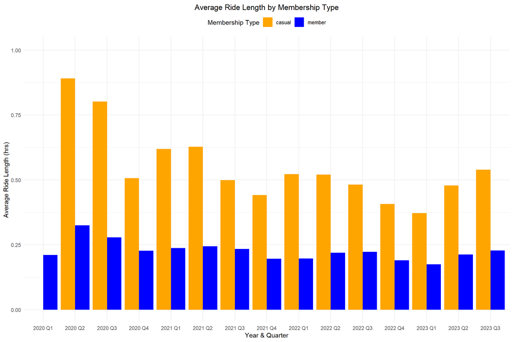

```r
#create a plot to view the average ride length by membership type
avg_length_by_membership <- ggplot(summary_by_membership, aes(x = year_qtr, y = mean_ride_length_hrs, fill = member_casual)) +
  geom_col(position = "dodge") +  #create clustered column chart
  labs(
    x = "Year & Quarter",
    y = "Average Ride Length (hrs)",
    fill = "Membership Type") +   #titles for axes and legend
  theme_minimal() +
  ggtitle("Average Ride Length by Membership Type") +   #create title for the chart
  theme(plot.title = element_text(hjust = 0.5, vjust = 0.5),legend.position = "top") +  #center the chart title
  ylim(0,1) +  #set the parameters for the y axis
  scale_fill_manual(values = c("orange", "blue")) #pick the column colors for the chart

#run the avg_length_by_membership plot
avg_length_by_membership
```

[figure not shown]

```r
#after running the plot, remove an obvious outlier.
summary_by_membership <- subset(summary_by_membership, year_qtr != "2020 Q1")
```

Use factor and levels to order the day_of_week column. This helps to order the legend in the next plot.

```r
#establish levels of the day of the week column so they are ordered from Sunday to Saturday
summary_by_day$day_of_week <- factor(summary_by_day$day_of_week, levels = c("Sunday", "Monday", "Tuesday", "Wednesday", "Thursday", "Friday", "Saturday"))
```

Create a line chart to view the average ride length per day of the week over time and store it in avg_length_per_day. Call on avg_length_per_day to see the plot.

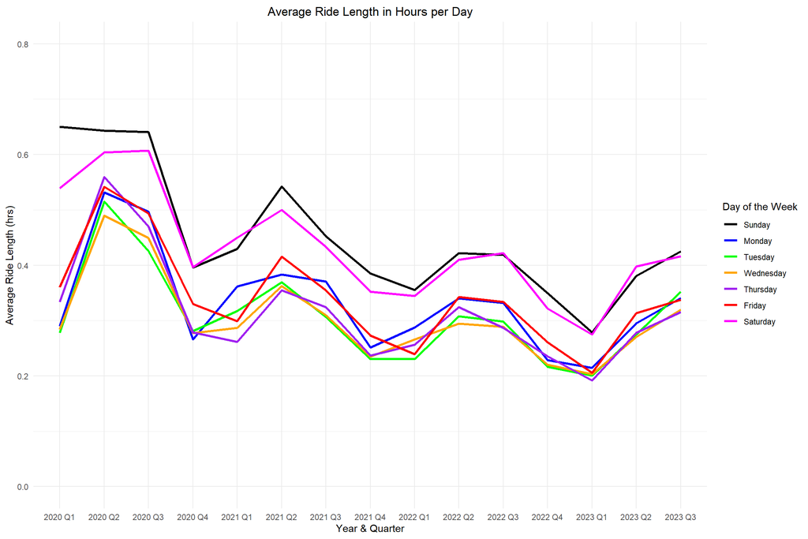

```r
#create a plot for the ride length per day of the week
avg_length_per_day <- ggplot(summary_by_day, aes(x = year_qtr, y = mean_ride_length_hrs, group = day_of_week, color = day_of_week)) +
  geom_line(size = 1.2) +  #make a line chart and increase the size of the lines
  labs(
    x = "Year & Quarter",
    y = "Average Ride Length (hrs)",
    color = "Day of the Week",
    title = "Average Ride Length in Hours per Day") + #chart labels
  theme_minimal() +
  theme(plot.title = element_text(hjust = 0.5, vjust = 0.5)) + #center the chart title
  scale_color_manual(values = (c("Monday"= "blue", "Tuesday" = "green", "Wednesday" = "orange", "Thursday" = "purple", "Friday" = "red", "Saturday" = "magenta", "Sunday" = "black"))) + #assign colors to every day of the week
  ylim(0, 0.8) # set parameters for the y axis
```

Use factor to order day_of_week by Sunday - Saturday. Create a clustered column charts for average ride length per each day of the week grouped by member_casual. Remove outliers and rerun the plot.

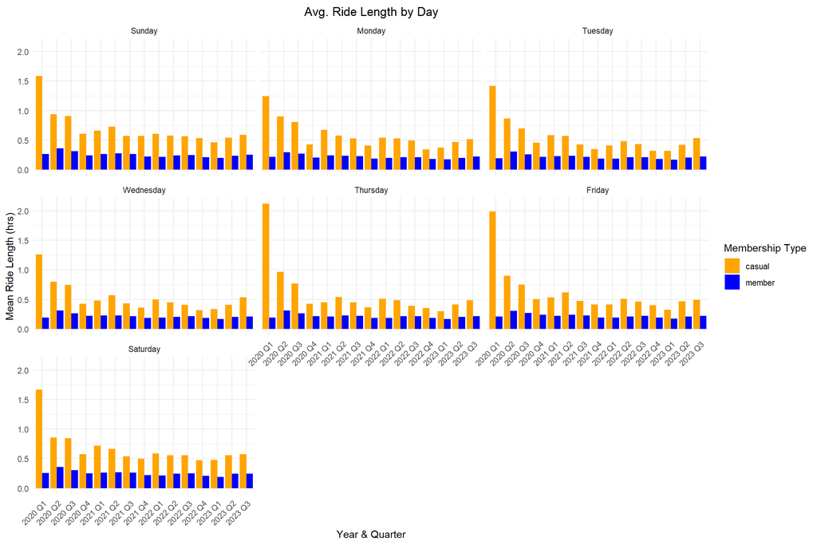

```r
#establish levels of the day of the week column so they are ordered from Sunday to Saturday
summary_all$day_of_week <- factor(summary_all$day_of_week, levels = c("Sunday", "Monday", "Tuesday", "Wednesday", "Thursday", "Friday", "Saturday"))

#create clustered column chart of avg ride length over time grouped by membership type and use facet wrap to make multiple charts, one for each day of the week
avg_length_day_membership <- ggplot(summary_all, aes(x = year_qtr, y = mean_ride_length_hrs, fill = member_casual)) +
  geom_bar(stat = "identity", position = "dodge") +
  facet_wrap(.~day_of_week, nrow = 3) +
  labs(
    x = "Year & Quarter",
    y = "Mean Ride Length (hrs)",
    fill = "Membership Type",
    title= "Avg. Ride Length by Day") +
  theme_minimal()+
  scale_fill_manual(values = c("orange", "blue"))+
  theme(axis.text.x = element_text(angle = 45, hjust = 1), plot.title = element_text(hjust = 0.5, vjust = 0.5))

#run the plot
avg_length_day_membership
```

```r
#remove outlying values
summary_all <- subset(summary_all, year_qtr != "2020 Q1")
```

[figure not shown]

Create another chart to see the number of rides casual users take throughout the week. To do this first filetr the data by casual users, then make the plot using the new filtered data.

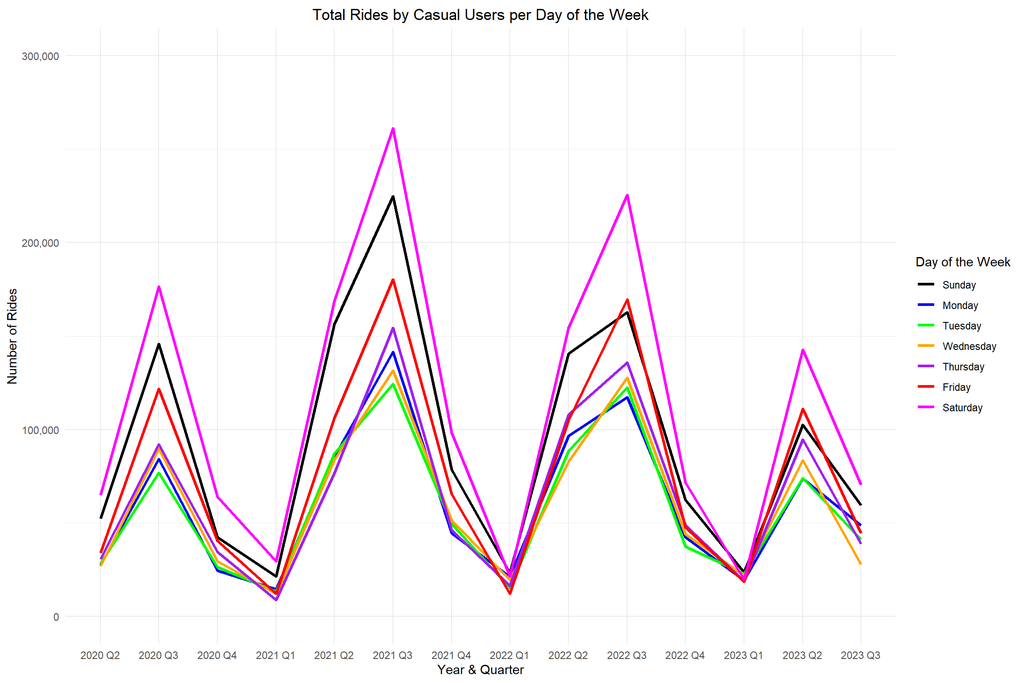

```r
#filter the summary by casual members
summary_casual <- subset(summary_all, member_casual == "casual")

#create a line chart to view only casual users and the number of rides they take throughout the week
count_day_casual <- ggplot(summary_casual, aes(x = year_qtr, y = count, group = day_of_week, color = day_of_week)) +
  geom_line(size = 1.2) +  #make a line chart and increase the size of the lines
  labs(
    x = "Year & Quarter",
    y = "Number of Rides",
    color = "Day of the Week",
    title = "Total Rides by Casual Users per Day of the Week") + #chart labels
  theme_minimal() +
  theme(plot.title = element_text(hjust = 0.5, vjust = 0.5)) +
  scale_color_manual(values = (c("Monday"= "blue", "Tuesday" = "green", "Wednesday" = "orange", "Thursday" = "purple", "Friday" = "red", "Saturday" = "magenta", "Sunday" = "black")))+
  scale_y_continuous(labels = scales::comma, limits = c(0, 300000), breaks = seq(0, 300000, by = 100000))
```

## Resources

Divvy public [data](https://divvy-tripdata.s3.amazonaws.com/index.html)